# ManagHAL

## Production de Aubert Julie

**Date :** 08/07/2024

### Compostion du rapport :

**Recherche** pour l'id HAL: 15356 du **01/01/2010** jusqu'au **01/01/2020**.

**Résultats demandés** (format csv, et maximum 1000 items):  
docid, halId_s, version_i, docType_s, citationFull_s, citationRef_s, publicationDate_tdate, authFullNamePersonIDIDHal_fs  
**Items triés** par producedDate_tdate, desc (dans l'ordre)

**Items filtré par:**

- docType_s = COMM, ART, OUV, COUV, DOUV, POSTER, SOFTWARE, THESE ou HDR

**Items exclu si:**

- status_i = 111
- instance_s = sfo, dumas, memsic ou hceres
- Document = notices ou annexes de Thèses ou HDR

### Les productions :

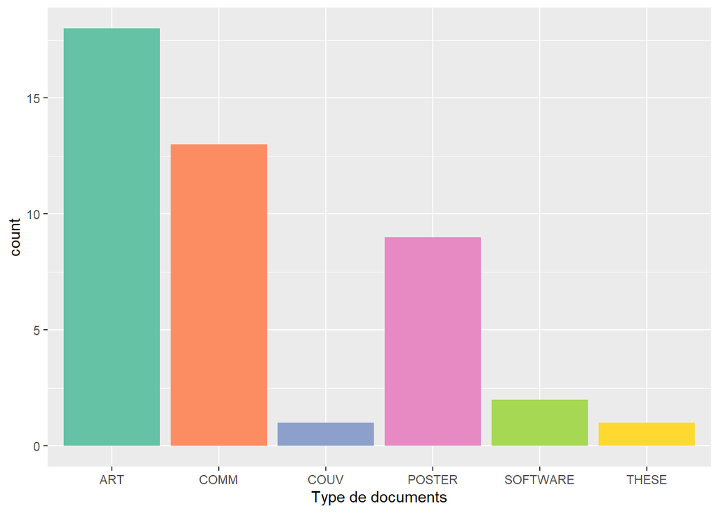

#### Article dans une revue

1 - Xiaoqiang Wang, Emilie Lebarbier, Julie Aubert, Stephane Robin. Variational inference for coupled hidden markov models applied to the joint detection of copy number variations. The international journal of biostatistics, 2019, 15 (1), ⟨10.1515/ijb-2018-0023⟩. ⟨hal-02626026⟩

2 - Mariam Raliou, Doulaye Dembélé, Anna Düvel, Philippe Bolifraud, J. Aubert, et al.. Subclinical endometritis in dairy cattle is associated with distinct mRNA expression patterns in blood and endometrium. PLoS ONE, 2019, 14 (8), ⟨10.1371/journal.pone.0220244⟩. ⟨hal-02264367⟩

3 - Héloïse Chassé, Julie Aubert, Sandrine Boulben, Gildas Le corguillé, Erwan Corre, et al.. Translatome analysis at the egg-to-embryo transition in sea urchin. Nucleic Acids Research, 2018, 46 (9), pp.4607 - 4621. ⟨10.1093/nar/gky258⟩. ⟨hal-01803500⟩

4 - Reine Malek, Pascal Bonnarme, Francoise Irlinger, Pascale Frey-Klett, Djamila Onesime, et al.. Transcriptomic response of Debaryomyces hansenii during mixed culture in a liquid model cheese medium with Yarrowia lipolytica. International Journal of Food Microbiology, 2018, 264, pp.53-62. ⟨10.1016/j.ijfoodmicro.2017.10.026⟩. ⟨hal-01695894⟩

5 - Tom Lachaise, Morgane Ourry, Lionel Lebreton, Anne-Yvonne Guillerm-Erckelboudt, Juliette Linglin, et al.. Can soil microbial diversity influence plant metabolites and life history traits of a rhizophagous insect?: A demonstration in oilseed rape.. Insect Science, 2017, 24 (6), pp.1045-1056. ⟨10.1111/1744-7917.12478⟩. ⟨hal-01661250⟩

6 - Eric Dugat-Bony, Cecile Straub, Aurélie Teissandier, Djamila Onesime, Valentin Loux, et al.. Overview of a surface-ripened cheese community functioning by meta-omics analyses. PLoS ONE, 2015, 10 (4), pp.e0124360. ⟨10.1371/journal.pone.0124360⟩. ⟨hal-01195505⟩

7 - Jenny Veide Vilg, Nallani Vijay Kumar, Ewa Maciaszczyk-Dziubinska, Ewa Sloma, Djamila Onesime, et al.. Elucidating the response of Kluyveromyces lactis to arsenite and peroxide stress and the role of the transcription factor KlYap8. Biochimica et Biophysica Acta - Gene Regulatory Mechanisms , 2014, 1839 (11), pp.1295-1306. ⟨10.1016/j.bbagrm.2014.09.004⟩. ⟨hal-03274354⟩

8 - Jenny Veide Vilg, Nallani Vijay Kumar, Ewa Maciaszczyk-Dziubinska, Ewa Sloma, Djamila Onesime, et al.. Elucidating the response of Kluyveromyces lactis to arsenite and peroxide stress and the role of the transcription factor KlYap8. Biochimica et Biophysica Acta - Gene Regulatory Mechanisms , 2014, 1839 (11), pp.1295 - 1306. ⟨10.1016/j.bbagrm.2014.09.004⟩. ⟨hal-01197637⟩

9 - Agnes A. Hebert, Marie-Pierre M.-P. Forquin, Aurelie A. Roux, Julie J. Aubert, Christophe C. Junot, et al.. New insights into sulfur metabolism in yeasts as revealed by studies of yarrowia lipolytica. Applied and Environmental Microbiology, 2013, 79 (4), pp.1200 - 1211. ⟨10.1128/AEM.03259-12⟩. ⟨hal-01001589⟩

10 - Marion Dalmasso, Julie Aubert, Sergine Even, Hélène Falentin, Marie-Bernadette Maillard, et al.. Accumulation of Intracellular Glycogen and Trehalose by Propionibacterium freudenreichii under Conditions Mimicking Cheese Ripening in the Cold. Applied and Environmental Microbiology, 2012, 78 (17), pp.6357-6364. ⟨10.1128/AEM.00561-12⟩. ⟨hal-02363390⟩

11 - Marion Dalmasso, Julie Aubert, Valérie Briard-Bion, Victoria Chuat, Stéphanie-Marie Deutsch, et al.. Correction: A Temporal -omic Study of Propionibacterium freudenreichii CIRM-BIA1 T Adaptation Strategies in Conditions Mimicking Cheese Ripening in the Cold. PLoS ONE, 2012, 7 (4), ⟨10.1371/annotation/e0ff065d-a52d-44f2-8727-328393ed60b6⟩. ⟨hal-02363413⟩

12 - Marion Dalmasso, Julie Aubert, Valérie Briard-Bion, Victoria Chuat, Stéphanie-Marie Deutsch, et al.. A Temporal -omic study of propionibacterium freudenreichii CIRM-BIA1T adaptation strategies in conditions mimicking cheese ripening in the cold. PLoS ONE, 2012, 7 (1), pp.e29083 (1-15). ⟨10.1371/journal.pone.0029083⟩. ⟨hal-01189567⟩

13 - Marion Dalmasso, Julie Aubert, Sergine Even, Hélène Falentin, Marie-Bernadette Maillard, et al.. Accumulation of intracellular glycogen and trehalose by [i]Propionibacterium Freudenreichii[/i] under conditions mimicking cheese ripening in the cold. Applied and Environmental Microbiology, 2012, 78 (17), pp.6357-6364. ⟨10.1128/AEM.00561-12⟩. ⟨hal-01191223⟩

14 - Marie-Agnès Dillies, Andrea Rau, Julie Aubert, Christelle Hennequet-Antier, Marine Jeanmougin, et al.. A comprehensive evaluation of normalization methods for Illumina high-throughput RNA sequencing data analysis. Briefings in Bioinformatics, 2012, 14 (6), pp.671-683. ⟨10.1093/bib/bbs046⟩. ⟨hal-00782486⟩

15 - Nathalie N. Ledée, Carine C. Munaut, Julie J. Aubert, Valérie V. Sérazin, Mona M. Rahmati, et al.. Specific and extensive endometrial deregulation is present before conception in IVF/ICSI repeated implantation failures (IF) or recurrent miscarriages. Journal of Pathology, 2011, 225 (4), pp.554-564. ⟨10.1002/path.2948⟩. ⟨hal-01000290⟩

16 - Agnes A. Hebert, Marie-Pierre Forquin Forquin-Gomez, Aurélie A. Roux, Julie J. Aubert, Christophe C. Junot, et al.. Exploration of sulfur metabolism in the yeast Kluyveromyces lactis. Applied Microbiology and Biotechnology, 2011, 91 (5), pp.1409-1423. ⟨10.1007/s00253-011-3481-2⟩. ⟨hal-01000029⟩

17 - M. Abdelkarim, N. Vintonenko, A. Starzec, A. Robles, J. Aubert, et al.. Invading basement membrane matrix is sufficient for MDA-MB-231 breast cancer cells to develop a atable in vivo metastatic phenotype. PLoS ONE, 2011, 6 (8), pp.e23334. ⟨10.1371/journal.pone.0023334⟩. ⟨hal-00705949⟩

18 - Marie-Pierre M.-P. Forquin, Agnes A. Hebert, Aurélie A. Roux, Julie J. Aubert, Caroline C. Proux, et al.. Global regulation of the response to sulfur availability in the cheese-related bacterium Brevibacterium aurantiacum. Applied and Environmental Microbiology, 2011, 77 (4), pp.1449-1459. ⟨10.1128/AEM.01708-10⟩. ⟨hal-01000027⟩

#### Communication dans un congrès

1 - Anouk Zancarini, Christine Le Signor, Julie J. Aubert, Sébastien Terrat, Joëlle Ronfort, et al.. Plant genotype: a lever in the interactions between plant and its associated rhizosphere microbiome. 2nd Plant Microbiome Symposium, Feb 2018, Amsterdam, Netherlands. ⟨hal-04081016⟩

2 - Julie Aubert, Sophie Schbath, Stephane Robin. Latent Block Model for metagenomic data. 17. Journées Ouvertes Biologie Informatique Mathématiques (JOBIM 2016), Jun 2016, Lyon, France. ⟨hal-01661249⟩

3 - Christophe Mougel, Julie Aubert, Lydia Bousset, Anne-Marie Cortesero, Stéphanie Daval, et al.. Quels effets la diversité microbienne du sol a-t-elle sur la croissance et la santé des plantes ?. Colloque de Génomique Environnementale, Oct 2015, Montpellier, France. ⟨hal-03349078⟩

4 - Julie Aubert, Sophie Schbath, Christophe Mougel, Stephane Robin. Latent Block Model for ecological abundance data. 30. European Meeting of Statisticians, Jul 2015, Amsterdam, Netherlands. ⟨hal-01661254⟩

5 - Julie Aubert. Latent Block Model for ecological abundance data. ISB Channel Network, Apr 2015, Nimègues, Netherlands. ⟨hal-01661253⟩

6 - Julie Aubert, Sophie Schbath, Béatrice Laroche. Metagenomics data analysis using a latent block model: application to plant-microbial communities interactions in the rhizosphere .. ECMTB14 - European Conference on Mathematical and Theoretical Biology, Jun 2014, Gôteborg, Sweden. pp.1. ⟨hal-01197629⟩

7 - Julie Aubert. Modèle à blocs latents pour l’analyse de données métagénomiques. 46. Journées de Statistique, Jun 2014, Rennes, France. ⟨hal-01197625⟩

8 - Julie Aubert, Frédéric Fer, Jean-Marie Beckerich. Resilience in a cheese ecosystem. 14. Journées Ouvertes en Biologie, Informatique et Mathématiques - JOBIM 2013, Jul 2013, Toulouse, France. ⟨hal-01661259⟩

9 - Xiaoqiang Wang, Julie J. Aubert, Stephane S. Robin. A multivariate HMM with dependency structure for the detection of copy number variations . 45e Journées de Statistique de la SfDS, May 2013, Toulouse, France. ⟨hal-01589538⟩

10 - Julie Aubert. An evaluation of normalization methods for the sequencing depth bias in comparative metagenomics studies. 5. Workshop Statistical Methods for Post-Genomic Data (SMPGD), Jan 2013, Amsterdam, Netherlands. ⟨hal-01661252⟩

11 - Julie Aubert, Marie-Agnes Dillies, Andrea Rau, Christelle Hennequet-Antier, Marine Jeanmougin, et al.. Comprehensive evaluation of normalization methods for High-throughput rnaSequencing Data analysis. 4 Workshop of StatSeq COST Action TD0801, Apr 2012, Vérone, Italy. ⟨hal-01661260⟩

12 - Julie Aubert, Jean-Jacques Daudin. On the use of the negative binomial regression model for comparing differential expression or abundance with ngs data. 12.Journées Ouvertes en Biologie, Informatique et Mathématiques - JOBIM 2011, Institut Pasteur [Paris]. FRA., Jun 2011, Paris, France. ⟨hal-01661248⟩

13 - Gérard Chaouat, Nathalie Rodde, Marie Petitbarat, Roberta Bulla, Mona Rahmati, et al.. An insight into normal and pathological pregnancies using large-scale microarrays: lessons from microarrays. 7. International Workshop on Reproductive Immunology, Immunological Tolerance and Immunology of Preeclampsia, European Society for Reproductive Immunology (ESRI). POL., Aug 2010, Tioman Island, Malaysia. ⟨10.1016/j.jri.2010.12.006⟩. ⟨hal-01239519⟩

#### Chapitre d'ouvrage

1 - Pierre Peyret, Julie Aubert, Vincent Breton, François Enault, Line Le Gall, et al.. Qualité des données NGS : de la séquence aux bases de données. La génomique environnementale, ISTE Editions, 180 p., 2016, 978-1-78405-151-8. ⟨hal-01661251⟩

#### Poster de conférence

1 - Sana Romdhane, Aymé Spor, Julie Aubert, David Bru, Marie-Christine Breuil, et al.. Unraveling biotic interactions determining soil microbial community assembly and functioning. IX. Colloque de l’Association Francophone d’Ecologie Microbienne, AFEM 2019, Fonctions et diversité des microbiotes dans les environnements naturels et anthropisés, Nov 2019, Bussang, France. , 2019. ⟨hal-02737617⟩

2 - Julie Aubert, Xiaoqiang Wang, Emilie Lebarbier, Stephane Robin. CHMM : an R package for coupled Hidden Markov Models. R User Conference 2017, Jul 2017, Bruxelles, Belgium. 2017. ⟨hal-01661257⟩

3 - Julie Aubert, Sophie Schbath, Stephane Robin. Latent Block Model for metagenomic data. 15. European Conference on Computational Biology (ECCB 2016), Workshop “Recent Computational Advances in Metagenomics (RCAM)”, Sep 2016, La Haye, Netherlands. , 2016, Proceedings of the 15th European Conference on Computational Biology (ECCB 2016), Workshop “Recent Computational Advances in Metagenomics (RCAM)”. ⟨hal-01661258⟩

4 - Julie Aubert, Christelle Hennequet-Antier, Cyprien Guerin, Delphine Labourdette, Anne de La Foye, et al.. How to Design a good RNA-Seq experiment in an interdisciplinary context?. European conference on Computational Biology, Sep 2014, Strasbourg, France. , 2014. ⟨hal-01462728⟩

5 - Julie Aubert, Frédéric Fer, Jean-Marie Beckerich. Combining kinetic modeling and transcriptomic analysis to study the resilience 2014 on a model of microbial ecosystem. ECCB’14 : European Conference on Computational Biology, Sep 2014, Strasbourg, France. , 2014, Proceedings of the 14ème European Conference on Computational Biology. ⟨hal-01661256⟩

6 - Clémentine Lepinay, Céline Faivre-Primot, Florence Deau, Julie Aubert, Sébastien Terrat, et al.. Soil microbial diversity effects on primary production and symbiotic interactions. 32. New Phytologist Symposium. Plant interactions with other organisms: molecules, ecology and evolution, Nov 2013, Buenos Aires, Argentina. , 2013. ⟨hal-01197630⟩

7 - A. Hébert, M.P. Forquin, J. Aubert, S. Luiggi, S. Landaud, et al.. Analyse de l’expression de Kluyveromyces lactis en interaction avec Brevibacterium aurantiacum . Journées des Microbiologistes de l’INRA, Nov 2012, L’Isle-sur-la-Sorgue, France. 2012. ⟨hal-01566447⟩

8 - Marion Dalmasso, Julie Aubert, Stéphanie-Marie Deutsch, Hélène Falentin, J. Tanskanen, et al.. Stratégie d’adaptation et de survie de Propionibacterium freudenreichii dans des conditions simulant celle du fromage à basse température. Journéés des Microbiologistes de l’INRA 2012, Nov 2012, L’Isle sur la Sorgue, France. , 2012. ⟨hal-01191287⟩

9 - Marion Dalmasso, Julie Aubert, Stéphanie-Marie Deutsch, Hélène Falentin, J. Tanskanen, et al.. Adaptation and survival strategies of Propionibacterium freudenreichii under conditions mimicking cheese ripening in the cold. 6.IDF Cheese Ripening & Technology Symposium, May 2012, Madison, France. , 2012. ⟨hal-01191245⟩

#### Logiciel

1 - Julie Aubert. cobiclust: Biclustering via Latent Block Model Adapted to Overdispersed Count Data. 2018, ⟨swh:1:dir:b76ffd82ce2f270ad548bf4df9ab9f46ca53a3bf;origin=https://cran.r-project.org/package%3Dcobiclust;visit=swh:1:snp:b65946d4ccbf2ce41b8c9f2fe68f9b23f2bc2c0e;anchor=swh:1:rel:1b4d5f893e459e3c922581321f112decf6c807ae⟩. ⟨hal-04532764⟩

2 - Julie Aubert, Xiaoqiang Wang. CHMM: Coupled Hidden Markov Models. 2017, ⟨swh:1:dir:931f86746bd8648062f8c78ac1cbe52864f3eeb2;origin=https://cran.r-project.org/package%3DCHMM;visit=swh:1:snp:a71f470404d95f6dfa1d172fd23c8ad7728347c1;anchor=swh:1:rel:cd36fa2bc45e5211ef524cdf219350e358a40713⟩. ⟨hal-04532830⟩

#### Thèse

1 - Julie Aubert. Analyse statistique de données biologiques à haut débit. Statistiques [math.ST]. Université Paris Saclay (COmUE), 2017. Français. ⟨NNT : 2017SACLS048⟩. ⟨tel-01721318⟩

### Vérifier vos résultats :

Pour voir vos productions sur HAL vous pouvez accèder via cette REQUETE RAPIDE